# Diaptera wings classification using Topological Data Analysis

Authors

Affiliation

Guilherme Vituri F. Pinto

Universidade Estadual Paulista

Sergio Ura

Northon

Published

February 10, 2026

Abstract

Keywords

Topological Data Analysis, Persistent homology

## 2 Methods

All images are in the `images/processed` directory. For each image, we load it, apply a gaussian blur, crop and make it have 150 pixels of height. The blurring step is necessary to “glue” small holes in the figure and keep it connected.

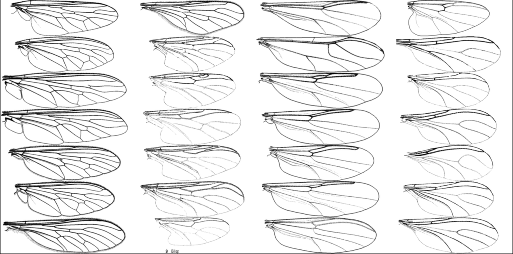

Source: Article Notebook

### 2.1 Vietoris-Rips filtration

We select 1000 points from each image using a farthest point sample method

and create an empty dictionary to store all computations

We then calculate its persistence diagrams using the Vietoris-Rips filtration etc.

We create the 1-dimensional persistence image for each persistence diagram using 10x10 matrices

#### 2.1.1 Examples

Below are some examples of 1-dimensional barcodes, its persistence image and the original wing that generated it. Note: we are plotting the barcode using the birth and persistence.

[figure not shown]

We now calculate the Euclidean distance between each persistence image (seen as a vector of $\mathbb{R}^{10x10}$) and plot its heatmap

[figure not shown]

## 3 TDA Statistics Analysis

We extract summary statistics from each 1-dimensional persistence diagram. These statistics capture different aspects of the topological structure:

- **Number of intervals**: Total count of 1-dimensional features (loops)
- **Maximum persistence**: The longest-lived feature
- **Total persistence**: Sum of all persistence values
- **Quantiles (10%, 25%, 50%, 75%, 90%)**: Distribution of persistence values, capturing the range of feature sizes
- **Persistence entropy**: Normalized Shannon entropy of persistence values

28×11 DataFrame

3 rows omitted

| Row | sample String | family String | n_intervals Float64 | max_pers Float64 | total_pers Float64 | q10 Float64 | q25 Float64 | median_pers Float64 | q75 Float64 | q90 Float64 | entropy Float64 |
| --- | --- | --- | --- | --- | --- | --- | --- | --- | --- | --- | --- |
| 1 | A-11 | Asilidae | 19.0 | 44.5913 | 317.473 | 7.68526 | 9.7272 | 14.095 | 23.4534 | 26.8707 | 2.79888 |
| 2 | A-13 | Asilidae | 16.0 | 44.7754 | 309.573 | 10.1541 | 13.8257 | 19.0883 | 22.3423 | 25.9931 | 2.6816 |
| 3 | A-17 | Asilidae | 21.0 | 42.2645 | 373.431 | 6.74034 | 7.61484 | 17.0121 | 28.2311 | 31.2565 | 2.86192 |
| 4 | A-19 | Asilidae | 19.0 | 55.6298 | 356.65 | 7.53879 | 8.47607 | 15.6072 | 24.6924 | 32.6072 | 2.74387 |
| 5 | A-2 | Asilidae | 17.0 | 32.6481 | 266.623 | 6.4803 | 10.5244 | 15.5563 | 19.1897 | 23.6704 | 2.72784 |
| 6 | A-3 | Asilidae | 17.0 | 40.0583 | 322.408 | 9.32151 | 11.3821 | 17.7798 | 22.6658 | 32.9423 | 2.71524 |
| 7 | A-5 | Asilidae | 14.0 | 25.3172 | 231.278 | 8.51681 | 11.282 | 17.2885 | 21.3117 | 23.7561 | 2.57048 |
| 8 | A-7 | Asilidae | 13.0 | 36.6085 | 228.359 | 8.77255 | 11.9065 | 18.5969 | 20.9468 | 27.8284 | 2.45892 |
| 9 | B-6 | Bibionidae | 13.0 | 44.9956 | 216.767 | 6.73958 | 7.64911 | 10.8937 | 22.798 | 31.6007 | 2.33695 |
| 10 | B-10 | Bibionidae | 12.0 | 41.5616 | 202.899 | 6.33931 | 8.87366 | 12.6686 | 21.8497 | 31.4075 | 2.2895 |
| 11 | B-11 | Bibionidae | 13.0 | 46.2253 | 251.813 | 6.05266 | 6.23176 | 15.8087 | 28.835 | 40.1721 | 2.32567 |
| 12 | B-7 | Bibionidae | 12.0 | 46.9464 | 205.191 | 6.05011 | 8.36803 | 13.0062 | 20.7013 | 31.1166 | 2.27155 |
| 13 | B-8 | Bibionidae | 12.0 | 37.6261 | 240.284 | 6.26571 | 11.9472 | 15.0829 | 30.2665 | 36.8773 | 2.31658 |
| ⋮ | ⋮ | ⋮ | ⋮ | ⋮ | ⋮ | ⋮ | ⋮ | ⋮ | ⋮ | ⋮ | ⋮ |
| 17 | C-40 | Ceratopogonidae | 12.0 | 57.1657 | 260.564 | 5.73802 | 9.07402 | 12.4407 | 33.8675 | 39.6792 | 2.2085 |
| 18 | C-41 | Ceratopogonidae | 9.0 | 61.5969 | 244.281 | 7.43264 | 12.1145 | 29.6731 | 35.684 | 48.3918 | 1.97516 |
| 19 | C-42 | Ceratopogonidae | 13.0 | 51.5007 | 250.896 | 5.33277 | 6.25209 | 12.0632 | 31.2535 | 41.4495 | 2.2431 |
| 20 | C-43 | Ceratopogonidae | 13.0 | 55.2018 | 261.51 | 6.04219 | 6.72096 | 14.5987 | 32.7299 | 39.3683 | 2.28324 |
| 21 | C-44 | Ceratopogonidae | 10.0 | 42.9235 | 232.72 | 7.2769 | 9.84804 | 22.5212 | 36.3017 | 39.5166 | 2.11038 |
| 22 | C-45 | Ceratopogonidae | 10.0 | 58.7915 | 251.153 | 7.53009 | 9.40727 | 25.7892 | 33.6927 | 41.5725 | 2.0882 |
| 23 | S-17 | Sciaridae | 10.0 | 39.1664 | 206.986 | 6.88409 | 7.72637 | 18.6091 | 34.2095 | 36.4724 | 2.07628 |
| 24 | S-18 | Sciaridae | 7.0 | 45.0079 | 206.799 | 11.3838 | 21.7662 | 33.2402 | 39.1903 | 41.6043 | 1.82865 |
| 25 | S-19 | Sciaridae | 11.0 | 45.4004 | 237.17 | 5.97516 | 6.32839 | 8.75697 | 37.6326 | 42.7812 | 2.08044 |
| 26 | S-14 | Sciaridae | 7.0 | 44.7445 | 214.848 | 14.8672 | 26.8292 | 34.2636 | 37.2236 | 41.5322 | 1.85651 |
| 27 | S-15 | Sciaridae | 9.0 | 39.0501 | 205.267 | 7.23954 | 9.31782 | 27.9319 | 34.5251 | 36.1454 | 2.01325 |
| 28 | S-16 | Sciaridae | 7.0 | 46.4363 | 189.849 | 8.68403 | 18.2932 | 29.5409 | 34.6645 | 40.0569 | 1.81347 |

### 3.1 Statistics comparison by family

[figure not shown]

## 4 Distance Matrix Comparison

We compute multiple distance metrics between persistence diagrams to compare their effectiveness for classification:

1. **Euclidean distance** on persistence images (already computed)
2. **Bottleneck distance** - maximum over all matchings
3. **Wasserstein-1 distance** - optimal transport with q=1
4. **Wasserstein-2 distance** - optimal transport with q=2

[figure not shown]

## 5 Classification Results

We use k-nearest neighbors (k-NN) classification with leave-one-out cross-validation (LOOCV). With a small sample size, LOOCV is the optimal choice as it:

- Uses all but one sample for training in each fold
- Tests every sample exactly once
- Provides nearly unbiased error estimates

### 5.1 Labels

```
28-element Vector{String}:
 "Asilidae"
 "Asilidae"
 "Asilidae"
 "Asilidae"
 "Asilidae"
 "Asilidae"
 "Asilidae"
 "Asilidae"
 "Bibionidae"
 "Bibionidae"
 "Bibionidae"
 "Bibionidae"
 "Bibionidae"
 ⋮
 "Ceratopogonidae"
 "Ceratopogonidae"
 "Ceratopogonidae"
 "Ceratopogonidae"
 "Ceratopogonidae"
 "Ceratopogonidae"
 "Sciaridae"
 "Sciaridae"
 "Sciaridae"
 "Sciaridae"
 "Sciaridae"
 "Sciaridae"
```

### 5.2 Systematic comparison of all methods

8×5 DataFrame

| Row | distance String | k Int64 | n_correct Int64 | n_total Int64 | accuracy Float64 |
| --- | --- | --- | --- | --- | --- |
| 1 | Euclidean (PI) | 1 | 23 | 28 | 0.821429 |
| 2 | Euclidean (PI) | 3 | 23 | 28 | 0.821429 |
| 3 | Wasserstein-1 | 3 | 22 | 28 | 0.785714 |
| 4 | Wasserstein-2 | 3 | 22 | 28 | 0.785714 |
| 5 | Wasserstein-1 | 1 | 21 | 28 | 0.75 |
| 6 | Wasserstein-2 | 1 | 21 | 28 | 0.75 |
| 7 | Bottleneck | 1 | 18 | 28 | 0.642857 |
| 8 | Bottleneck | 3 | 18 | 28 | 0.642857 |

### 5.3 Best classifier evaluation

```
Best method: Euclidean (PI) with k=1
Accuracy: 23/28 (82.1%)
```

[output not shown]

### 5.4 Detailed classification report

```
=== Classification Report ===
Method: Euclidean (PI) + 1-NN
Accuracy: 23/28 (82.1%)
95% CI: [64.4%, 92.1%]
p-value: 0.0
Chance level: 22.7%

Per-class accuracy:
  Asilidae: 8/8 (100.0%)
  Bibionidae: 4/6 (66.7%)
  Ceratopogonidae: 6/8 (75.0%)
  Sciaridae: 5/6 (83.3%)
```

### 5.5 Confusion matrix

```
Confusion Matrix (rows = true, columns = predicted):
                      Asil  Bibi  Cera  Scia
Asilidae                 8     0     0     0
Bibionidae               0     4     0     2
Ceratopogonidae          0     0     6     2
Sciaridae                0     0     1     5
```

[figure not shown]

## 6 Alternative Metrics on PD Statistics

24×6 DataFrame

| Row | metric String | normalization String | k Int64 | n_correct Int64 | n_total Int64 | accuracy Float64 |
| --- | --- | --- | --- | --- | --- | --- |
| 1 | L2 | z-score | 3 | 24 | 28 | 0.857143 |
| 2 | L1 | z-score | 1 | 24 | 28 | 0.857143 |
| 3 | Cosine | z-score | 1 | 24 | 28 | 0.857143 |
| 4 | Cosine | z-score | 3 | 24 | 28 | 0.857143 |
| 5 | L1 | raw | 1 | 23 | 28 | 0.821429 |
| 6 | L1 | z-score | 3 | 23 | 28 | 0.821429 |
| 7 | L1 | z-score | 5 | 23 | 28 | 0.821429 |
| 8 | L2 | z-score | 1 | 22 | 28 | 0.785714 |
| 9 | L2 | z-score | 5 | 22 | 28 | 0.785714 |
| 10 | Cosine | raw | 1 | 22 | 28 | 0.785714 |
| 11 | Cosine | z-score | 5 | 22 | 28 | 0.785714 |
| 12 | L1 | raw | 3 | 21 | 28 | 0.75 |
| 13 | L∞ | z-score | 1 | 21 | 28 | 0.75 |
| 14 | L∞ | z-score | 3 | 21 | 28 | 0.75 |
| 15 | L∞ | z-score | 5 | 21 | 28 | 0.75 |
| 16 | Cosine | raw | 3 | 20 | 28 | 0.714286 |
| 17 | L2 | raw | 1 | 19 | 28 | 0.678571 |
| 18 | L2 | raw | 3 | 18 | 28 | 0.642857 |
| 19 | L1 | raw | 5 | 18 | 28 | 0.642857 |
| 20 | L∞ | raw | 1 | 18 | 28 | 0.642857 |
| 21 | L∞ | raw | 3 | 17 | 28 | 0.607143 |
| 22 | L∞ | raw | 5 | 15 | 28 | 0.535714 |
| 23 | L2 | raw | 5 | 14 | 28 | 0.5 |
| 24 | Cosine | raw | 5 | 14 | 28 | 0.5 |

## 7 Combined Distance Analysis

We combine the Wasserstein-1 distance (best topology-aware metric) with a statistics-based distance using convex combinations: $D_\text{combined}(\alpha) = \alpha \cdot D_1^* + (1 - \alpha) \cdot D_2^*$ where $D^*$ denotes the matrix normalized to $[0, 1]$.

### 7.1 Wasserstein-1 + Statistics (best metric)

```
Best statistics metric: L2 (z-score)

Top 5 combinations (Wasserstein-1 + Stats):
  α=0.0, k=3: 24/28 (85.7%)
  α=0.1, k=3: 24/28 (85.7%)
  α=0.2, k=3: 24/28 (85.7%)
  α=0.3, k=3: 24/28 (85.7%)
  α=0.4, k=3: 24/28 (85.7%)
```

[figure not shown]

### 7.2 Wasserstein-1 + Bottleneck

```
Top 5 combinations (Wasserstein-1 + Bottleneck):
  α=0.6, k=3: 22/28 (78.6%)
  α=0.7, k=3: 22/28 (78.6%)
  α=0.8, k=3: 22/28 (78.6%)
  α=0.8, k=5: 22/28 (78.6%)
  α=0.9, k=3: 22/28 (78.6%)
```

[figure not shown]

## 8 Alternative Representations

### 8.1 Persistence Landscapes and Betti Curves

6×5 DataFrame

| Row | representation String | k Int64 | n_correct Int64 | n_total Int64 | accuracy Float64 |
| --- | --- | --- | --- | --- | --- |
| 1 | Betti curve | 1 | 22 | 28 | 0.785714 |
| 2 | Betti curve | 3 | 20 | 28 | 0.714286 |
| 3 | Betti curve | 5 | 18 | 28 | 0.642857 |
| 4 | Landscape-1 | 3 | 13 | 28 | 0.464286 |
| 5 | Landscape-1 | 5 | 13 | 28 | 0.464286 |
| 6 | Landscape-1 | 1 | 12 | 28 | 0.428571 |

### 8.2 Combining Betti curves / Landscapes with Wasserstein-1

```
Top 3 (Wasserstein-1 + Betti curve):
  α=0.2, k=1: 23/28 (82.1%)
  α=0.3, k=1: 23/28 (82.1%)
  α=0.8, k=3: 23/28 (82.1%)

Top 3 (Wasserstein-1 + Landscape-1):
  α=0.8, k=3: 22/28 (78.6%)
  α=0.9, k=3: 22/28 (78.6%)
  α=0.9, k=5: 22/28 (78.6%)
```

## 9 Alternative Classifiers

We compare the standard k-NN with weighted k-NN (inverse distance weighting) and nearest centroid classification.

15×5 DataFrame

| Row | classifier String | distance String | k Int64 | n_correct Int64 | accuracy Float64 |
| --- | --- | --- | --- | --- | --- |
| 1 | Nearest centroid | Euclidean (PI) | 0 | 24 | 0.857143 |
| 2 | k-NN | Euclidean (PI) | 1 | 23 | 0.821429 |
| 3 | Weighted k-NN | Euclidean (PI) | 1 | 23 | 0.821429 |
| 4 | k-NN | Euclidean (PI) | 3 | 23 | 0.821429 |
| 5 | Weighted k-NN | Euclidean (PI) | 3 | 23 | 0.821429 |
| 6 | Nearest centroid | Wasserstein-2 | 0 | 23 | 0.821429 |
| 7 | k-NN | Euclidean (PI) | 5 | 22 | 0.785714 |
| 8 | Weighted k-NN | Euclidean (PI) | 5 | 22 | 0.785714 |
| 9 | k-NN | Wasserstein-1 | 3 | 22 | 0.785714 |
| 10 | Weighted k-NN | Wasserstein-1 | 3 | 22 | 0.785714 |
| 11 | Weighted k-NN | Wasserstein-1 | 5 | 22 | 0.785714 |
| 12 | Nearest centroid | Wasserstein-1 | 0 | 22 | 0.785714 |
| 13 | k-NN | Betti curve | 1 | 22 | 0.785714 |
| 14 | Weighted k-NN | Betti curve | 1 | 22 | 0.785714 |
| 15 | Nearest centroid | Betti curve | 0 | 22 | 0.785714 |

## 10 Honest Evaluation (Nested LOOCV)

Since we tested many (distance, α, k) configurations, we use **nested leave-one-out cross-validation** for an unbiased accuracy estimate. The outer loop leaves one sample out; the inner loop selects the best (α, k) on the remaining samples.

```
=== Nested LOOCV Result ===
Distance pair: Wasserstein-1 + Stats (L2, z-score)
Accuracy: 23/28 (82.1%)
95% CI: [64.4%, 92.1%]

Selected parameters per fold:
  Sample 1: α=0.0, k=3 (inner acc=85.2%)
  Sample 2: α=0.0, k=3 (inner acc=85.2%)
  Sample 3: α=0.0, k=3 (inner acc=85.2%)
  Sample 4: α=0.0, k=3 (inner acc=85.2%)
  Sample 5: α=0.0, k=3 (inner acc=85.2%)
  Sample 6: α=0.0, k=3 (inner acc=85.2%)
  Sample 7: α=0.0, k=3 (inner acc=85.2%)
  Sample 8: α=0.0, k=3 (inner acc=88.9%)
  Sample 9: α=0.0, k=3 (inner acc=88.9%)
  Sample 10: α=0.0, k=3 (inner acc=85.2%)
  Sample 11: α=0.1, k=3 (inner acc=88.9%)
  Sample 12: α=0.0, k=3 (inner acc=85.2%)
  Sample 13: α=0.1, k=3 (inner acc=88.9%)
  Sample 14: α=0.0, k=3 (inner acc=85.2%)
  Sample 15: α=0.0, k=3 (inner acc=85.2%)
  Sample 16: α=0.0, k=3 (inner acc=85.2%)
  Sample 17: α=0.1, k=3 (inner acc=81.5%)
  Sample 18: α=0.0, k=3 (inner acc=85.2%)
  Sample 19: α=0.2, k=5 (inner acc=85.2%)
  Sample 20: α=0.2, k=3 (inner acc=81.5%)
  Sample 21: α=0.1, k=3 (inner acc=92.6%)
  Sample 22: α=0.0, k=3 (inner acc=85.2%)
  Sample 23: α=0.1, k=3 (inner acc=88.9%)
  Sample 24: α=0.1, k=5 (inner acc=81.5%)
  Sample 25: α=0.0, k=3 (inner acc=88.9%)
  Sample 26: α=0.0, k=3 (inner acc=85.2%)
  Sample 27: α=0.6, k=3 (inner acc=85.2%)
  Sample 28: α=0.7, k=3 (inner acc=85.2%)
```

```
Per-class accuracy (Nested LOOCV):
  Asilidae: 7/8 (87.5%)
  Bibionidae: 4/6 (66.7%)
  Ceratopogonidae: 7/8 (87.5%)
  Sciaridae: 5/6 (83.3%)
```

[figure not shown]

## 11 Discussion

### 11.1 Limitations

- Small sample size (n=28) leads to wide confidence intervals; results should be confirmed with larger datasets
- Mild class imbalance (8 Asilidae, 6 Bibionidae, 8 Ceratopogonidae, 6 Sciaridae) may affect classification performance
- Image quality and preprocessing parameters may influence topological features
- Grid search over many configurations requires nested cross-validation to avoid overfitting

### 11.2 Future work

- Extend dataset with more species and specimens per family
- Explore additional filtration methods (line-based, directional)
- Combine TDA features with traditional morphometric measurements
- Investigate kernel methods for persistence diagrams (e.g., persistence scale-space kernel)